# Free Response

1. There is no "import" statement to let python know what packages to use, in this case qiskit. This can fixed by adding the following before the code:

```python
from qiskit import QuantumCircuit
```

or this which imports all classes from qiskit

```python
from qiskit import *
```

1. Like the statement right above, "import qiskit" will import all of qiskit, so QuantumCircuit() will be included in that import along with the rest of qiskit.

```python
import qiskit

circ = QuantumCircuit(1)

circ.draw()
```

```
q_0:
```

3.

```python
import qiskit

circ = QuantumCircuit(3)

for qubit in range(3):
    circ.h(qubit)

circ.draw()
```

```
     ┌───┐
q_0: ┤ H ├
     ├───┤
q_1: ┤ H ├
     ├───┤
q_2: ┤ H ├
     └───┘
```

4.

```python
import qiskit

circ = QuantumCircuit(1)

circ.x(0)
circ.y(0)

circ.draw()
```

```
     ┌───┐┌───┐
q_0: ┤ X ├┤ Y ├
     └───┘└───┘
```

1. Once you scroll down to $T gate$, you find that it can be called by using:

```python
import qiskit

##example circuit#
circ = QuantumCircuit(1)

##how to call T Gate##
circ.t(0)

##how it looks##
circ.draw()
```

```
     ┌───┐
q_0: ┤ T ├
     └───┘
```

# Challenge

1.

```python
##CASE A##

from qiskit import QuantumCircuit, Aer, execute

#create QuantumCircuit
circ=QuantumCircuit(1,1)

#Code for CASE A
circ.h(0) #first beamsplitter
circ.h(0) #second beamsplitter

#measure
circ.measure([0],[0])
backend_sim = Aer.get_backend('qasm_simulator')
sim = execute(circ, backend_sim, shots=1024)
sim_result = sim.result()
counts = sim_result.get_counts(circ)
print(counts)
```

```
{'0': 1024}
```

Just as expected from the no firework case, the photon will always choose Detector A, as shown that all counts measured $0$.

```python
##CASE B##

from qiskit import QuantumCircuit, Aer, execute

#create QuantumCircuit
circ=QuantumCircuit(1,1)

#Code for CASE B
circ.h(0) #first beamsplitter
circ.measure(0,0) #50% of the time, the firework explodes
circ.initialize([0,1], 0)

#measure
circ.measure([0],[0])
backend_sim = Aer.get_backend('qasm_simulator')
sim = execute(circ, backend_sim, shots=1024)
sim_result = sim.result()
counts = sim_result.get_counts(circ)
print(counts)
```

```
{'1': 1024}
```

We expect $50\%$ of the time the photon chooses the upper path (0), and $50\%$ cause the firework to explode (1). Since we are assuming the firework explodes for this case, we do not need to add another gate since the photon was measured in the explosion, initializing the measurement state to be $|1\rangle$.

```python
##CASE C##

from qiskit import QuantumCircuit, Aer, execute

#create QuantumCircuit
circ=QuantumCircuit(1,1)

#Code for CASE C
circ.h(0) #first beamsplitter
circ.measure(0,0) #say the upper path was chosen (0)
circ.initialize([1,0], 0) #initialize circuit to upper path
circ.h(0) #second beamsplitter
circ.measure(0,0) #determine which detector is hit

#measure
circ.measure([0],[0])
backend_sim = Aer.get_backend('qasm_simulator')
sim = execute(circ, backend_sim, shots=1024)
sim_result = sim.result()
counts = sim_result.get_counts(circ)
print(counts)
```

```
{'1': 501, '0': 523}
```

We see now that after we collapsed the state and chose the upper path (no firework went off), we initalize the state to now be $|0\rangle$. There is now a $50/50$ chance of choosing either Detector A or B, which comes from using the second beamsplitter (second $H$ gate).

- a) As you can see from the table, the measurement results for $|0\rangle$ and $|1\rangle$ are approximately $50/50$ or $50\%$ each.
- b) A qubit state that would yield similar results is $\frac{1}{\sqrt{2}}(|0\rangle+|1\rangle)$. This will give $Pr(|0\rangle)=50\%, Pr(|1\rangle)=50\%$.
- c) The qubit state above is the basic superposition state given by applying the $H$ gate to $|0\rangle$.

```
{'1': 514, '0': 510}
     ┌───┐┌─┐
q_0: ┤ H ├┤M├
     └───┘└╥┘
c_0: ══════╩═
```

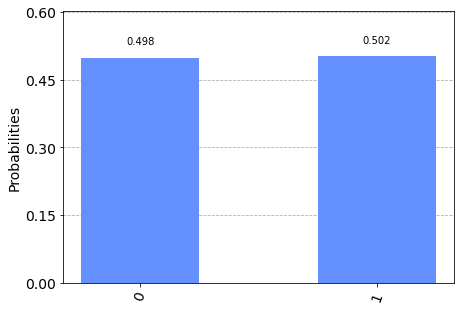

```python
from qiskit import QuantumCircuit
from qiskit.visualization import plot_histogram

circ = QuantumCircuit(1,1)  #create QuantumCircuit object
### START CODE HERE ### (approx. 1 lines)
circ.h(0)
### END CODE HERE ###
circ.measure(0,0) #add a measurement to the circuit


backend_sim = Aer.get_backend('qasm_simulator')
sim = execute(circ, backend_sim, shots=1024)
sim_result = sim.result()
counts = sim_result.get_counts(circ)
print(counts)
print(circ.draw())
plot_histogram(counts)
```

As we can see, we got about $50/50$ results upon measurement like with the last circuit.